# Season report: 4545 Season 7

#### Popular variations

All openings played in the season, including variations.

| Rank | Opening | Games | White % | 1-0 % | Draw % | 0-1 % | Mean Eval | Avg Rating |
| --- | --- | --- | --- | --- | --- | --- | --- | --- |
| 1 | Sicilian Defense: Najdorf Variation | 10 | 60 | 60 | 0 | 40 | 0.426 | 1869.9 |
| 2 | Giuoco Piano | 8 | 25 | 12.5 | 25 | 62.5 | -1.4175 | 1565 |
| 2 | Sicilian Defense: Closed | 8 | 50 | 37.5 | 25 | 37.5 | -0.51125 | 1812.6875 |
| 3 | Horwitz Defense | 7 | 64.2857142857143 | 42.8571428571429 | 42.8571428571429 | 14.2857142857143 | 0.428571428571429 | 1964.5 |
| 3 | Queen's Gambit Declined: Three Knights Variation | 7 | 71.4285714285714 | 57.1428571428571 | 28.5714285714286 | 14.2857142857143 | 0.08 | 1799.21428571429 |
| 4 | Queen's Gambit Declined | 6 | 75 | 66.6666666666667 | 16.6666666666667 | 16.6666666666667 | 0.192 | 1949.5 |
| 4 | Slav Defense | 6 | 16.6666666666667 | 0 | 33.3333333333333 | 66.6666666666667 | -3.07666666666667 | 1687.41666666667 |
| 5 | English Opening: King's English Variation, Reversed Closed Sicilian | 5 | 0 | 0 | 0 | 100 | -1.806 | 1853.6 |
| 5 | Indian Defense | 5 | 40 | 40 | 0 | 60 | -0.274 | 1883.8 |
| 5 | King's Indian Attack | 5 | 60 | 60 | 0 | 40 | 0.026 | 1919.8 |

[output cut: 374 more lines]

#### Best for White

The best-scoring main openings for White.

*Includes all main openings played in at least 10 games.*

| Rank | Opening | Games | White's score (%) | White wins (%) | Draws (%) | Black wins (%) | Mean eval after 15 moves | Avg rating |
| --- | --- | --- | --- | --- | --- | --- | --- | --- |
| 1 | Grünfeld Defense | 21 | 71.4285714285714 | 57.1428571428571 | 28.5714285714286 | 14.2857142857143 | 0.748571428571429 | 1845.30952380952 |
| 2 | Caro-Kann Defense | 29 | 65.5172413793103 | 65.5172413793103 | 0 | 34.4827586206897 | 0.248928571428571 | 1759.75862068966 |
| 3 | Zukertort Opening | 11 | 63.6363636363636 | 54.5454545454545 | 18.1818181818182 | 27.2727272727273 | 0.0181818181818182 | 1934.31818181818 |
| 4 | French Defense | 42 | 60.7142857142857 | 54.7619047619048 | 11.9047619047619 | 33.3333333333333 | 0.410238095238095 | 1825.61904761905 |
| 5 | Italian Game | 16 | 59.375 | 50 | 18.75 | 31.25 | 0.926 | 1816.28125 |
| 6 | Slav Defense | 27 | 57.4074074074074 | 44.4444444444444 | 25.9259259259259 | 29.6296296296296 | -0.53962962962963 | 1865.72222222222 |
| 7 | Queen's Gambit Declined | 49 | 56.1224489795918 | 44.8979591836735 | 22.4489795918367 | 32.6530612244898 | 0.77375 | 1856.92857142857 |
| 8 | King's Indian Defense | 27 | 51.8518518518518 | 40.7407407407407 | 22.2222222222222 | 37.037037037037 | 0.863703703703704 | 1874.68518518519 |
| 9 | Indian Defense | 16 | 50 | 37.5 | 25 | 37.5 | 0.291333333333333 | 1909.53125 |
| 9 | Scandinavian Defense | 21 | 50 | 42.8571428571429 | 14.2857142857143 | 42.8571428571429 | 1.54904761904762 | 1789.02380952381 |

[output cut: 7 more lines]

#### Best for Black

The best-scoring main openings for Black.

*Includes all main openings played in at least 10 games.*

| Rank | Opening | Games | Black's score (%) | Black wins (%) | Draws (%) | White wins (%) | Mean eval after 15 moves | Avg rating |
| --- | --- | --- | --- | --- | --- | --- | --- | --- |
| 1 | Nimzo-Indian Defense | 19 | 73.6842105263158 | 57.8947368421053 | 31.5789473684211 | 10.5263157894737 | -0.154736842105263 | 1868.71052631579 |
| 2 | Scotch Game | 18 | 63.8888888888889 | 50 | 27.7777777777778 | 22.2222222222222 | 0.466666666666667 | 1815.30555555556 |
| 3 | English Opening | 42 | 60.7142857142857 | 54.7619047619048 | 11.9047619047619 | 33.3333333333333 | -0.166585365853659 | 1940.55952380952 |
| 4 | Ruy Lopez | 47 | 58.5106382978723 | 51.063829787234 | 14.8936170212766 | 34.0425531914894 | 0.809347826086957 | 1863.67021276596 |
| 5 | Sicilian Defense | 100 | 54.5 | 48 | 13 | 39 | 0.734270833333333 | 1853.84 |
| 6 | Queen's Pawn Game | 12 | 54.1666666666667 | 41.6666666666667 | 25 | 33.3333333333333 | 1.35166666666667 | 1789.5 |
| 7 | Semi-Slav Defense | 15 | 53.3333333333333 | 40 | 26.6666666666667 | 33.3333333333333 | 1.02266666666667 | 1912.4 |
| 8 | Indian Defense | 16 | 50 | 37.5 | 25 | 37.5 | 0.291333333333333 | 1909.53125 |
| 8 | Scandinavian Defense | 21 | 50 | 42.8571428571429 | 14.2857142857143 | 42.8571428571429 | 1.54904761904762 | 1789.02380952381 |
| 9 | King's Indian Defense | 27 | 48.1481481481481 | 37.037037037037 | 22.2222222222222 | 40.7407407407407 | 0.863703703703704 | 1874.68518518519 |

[output cut: 7 more lines]

#### Popular gambits

All gambit openings played in the season.[^5]

| Rank | Name | Games | White score (%) |
| --- | --- | --- | --- |
| 1 | Smith-Morra Gambit | 10 | 50 |
| 2 | Benko Gambit | 4 | 75 |
| 3 | Scotch Gambit | 3 | 66.6666666666667 |
| 4 | Vienna Gambit | 3 | 16.6666666666667 |
| 5 | King's Gambit | 2 | 75 |
| 6 | Queen's Gambit | 2 | 25 |
| 7 | From's Gambit | 1 | 100 |
| 7 | Geller Gambit | 1 | 100 |
| 8 | Evans Gambit | 1 | 0 |
| 8 | Marshall Gambit | 1 | 0 |

[output cut: 2 more lines]

#### Gambiteers

The players who enjoyed the most success when playing gambits.[^6]

*Shows all players who scored at least 50% playing gambits in the season (min. games: 2).*

| Rank | Player | Games | % Score |
| --- | --- | --- | --- |
| 1 | jivey | 2 | 100 |
| 2 | arex | 2 | 50 |

### Openings - sunburst

Click on the image below to see a sunburst plot of all openings played in the season.

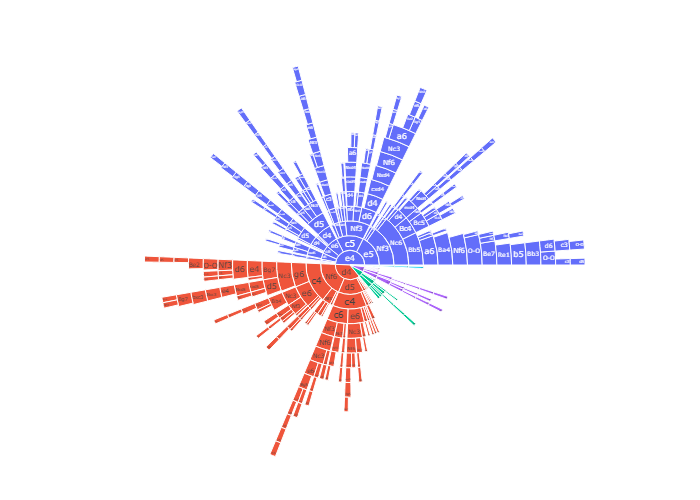

### Awards

Because winning isn’t everything; it’s the only thing :)

See the footnote for further details on selected awards.[^7]

| Award | Description | Winner | Details | Honourable mentions |
| --- | --- | --- | --- | --- |
| x | Archbishop of Accuracy | HappilyNumb | 16.4 ACPL over 108 moves | YunasGuardians, jameslatham |
| x | Awesome Alt | Lynnpv | Played for 4 different teams | bobwooster, cacheyourdreams, CaptNCarter, dkillian, foxxxy_coxxxy, HappilyNumb, Klip98, Malamutt (3) |
| x | Bullet Boss | InfernalJumble | 16 moves | TonyRo, lovlas |
| x | David Award | Lynnpv | Opponents' record: 22/30 | piotor, Anunzio |
| x | Egalitarian Award | Knight at the Rooksbury | SD: 61.4 |  |
| x | Gambit Guru | jivey | 100% from 2 games | NA |
| x | Giri Award | isaypotato | 5 draws |  |
| x | Grischuk's Cousin | DzeiTi | Had 13m 1s left after 10 moves | mingpro, Karpovian |
| x | Houdini Award | LuvGangster |  | Toffeeman, TheRatRiverTrapper |
| x | Intimate with Increment | mingpro | 24.9% | Asinya, kobol |

[output cut: 10 more lines]

### Detailed statistics

All the following tables are sortable and searchable.

#### Team statistics

[output not shown]

[output cut: 20 more lines]

#### Best performances / highest accuracy

##### Best relative perfs

Shows players’ *relative* performance ratings: season performance rating minus initial rating.[^8]

*Includes all players with a positive relative performance rating over at least five games.*

| # | Player | Games | W | D | L | Initial | Perf | Diff. |
| --- | --- | --- | --- | --- | --- | --- | --- | --- |
| 1 | S3pp | 5 | 4 | 1 | 0 | 1863 | 2294.8 | 431.8 |
| 2 | RazorBoy | 8 | 7 | 0 | 1 | 2097 | 2518.125 | 421.125 |
| 3 | cybercapitalist | 6 | 3 | 1 | 2 | 1161 | 1570.33333333333 | 409.333333333333 |
| 4 | Fuzz0410 | 5 | 4 | 1 | 0 | 2016 | 2413.2 | 397.2 |
| 5 | Toffeeman | 8 | 7 | 1 | 0 | 1611 | 1972.875 | 361.875 |
| 6 | piotor | 7 | 5 | 0 | 2 | 1340 | 1701.28571428571 | 361.285714285714 |
| 7 | Angstschreeuw | 6 | 5 | 0 | 1 | 1780 | 2118 | 338 |
| 8 | arex | 7 | 6 | 0 | 1 | 1705 | 2002.42857142857 | 297.428571428571 |
| 9 | cyanfish | 7 | 4 | 3 | 0 | 2167 | 2457.57142857143 | 290.571428571428 |
| 10 | smothermemate | 9 | 7 | 0 | 2 | 1513 | 1790.44444444444 | 277.444444444444 |

[output cut: 68 more lines]

##### Lowest ACPL

*Includes the 100 players with the lowest ACPL (min. 100 moves played).*

| Rank | Player | Moves | ACPL |
| --- | --- | --- | --- |
| 1 | HappilyNumb | 108 | 16.3518518518519 |
| 2 | YunasGuardians | 136 | 17.9705882352941 |
| 3 | jameslatham | 103 | 20.3106796116505 |
| 4 | obvious_cheater | 282 | 20.7659574468085 |
| 5 | Klip98 | 137 | 21.3503649635037 |
| 6 | god666 | 312 | 21.3878205128205 |
| 7 | Toffeeman | 297 | 21.6026936026936 |
| 8 | cyanfish | 394 | 21.7766497461929 |
| 9 | Fuzz0410 | 206 | 21.8300970873786 |
| 10 | Knoddel | 130 | 22.2538461538462 |

[output cut: 90 more lines]

#### Time spent / strongest opponents

##### Time spent

*Includes the 50 players who spent the most clock time over the season.*

| Rank | Player | Games | Total time spent |
| --- | --- | --- | --- |
| 1 | SMC | 8 | 10h 50m 51s |
| 2 | Aliquantus | 8 | 10h 29m 39s |
| 3 | mingpro | 8 | 9h 55m 12s |
| 4 | hetraie | 8 | 9h 51m 4s |
| 5 | cyanfish | 8 | 9h 36m 42s |
| 6 | isaypotato | 8 | 9h 36m 27s |
| 7 | MrLegilimens | 8 | 9h 32m 3s |
| 8 | chgreg | 8 | 9h 29m 12s |
| 9 | yeyq | 8 | 9h 18m 3s |
| 10 | RazorBoy | 8 | 9h 11m 39s |

[output cut: 40 more lines]

##### Time spent per move (after move 10)

*Includes everyone who played at least three games.*

| Rank | Player | Games | Moves | Time spent per move | Percentile |
| --- | --- | --- | --- | --- | --- |
| 1 | Cleave | 4 | 70 | 2m 33.2s | 100 |
| 2 | SuperIntegration | 6 | 125 | 2m 31.6s | 99 |
| 3 | ChukoDiman | 7 | 139 | 2m 23.9s | 98 |
| 4 | x_0 | 6 | 124 | 2m 19.3s | 97 |
| 5 | jivey | 7 | 122 | 2m 18.3s | 96 |
| 6 | metalpawn | 8 | 118 | 2m 18.0s | 95 |
| 7 | Kilderis | 6 | 124 | 2m 15.6s | 94 |
| 8 | CarlosSilva96 | 6 | 135 | 2m 11.3s | 93 |
| 9 | Malamutt | 3 | 57 | 2m 10.5s | 92 |
| 10 | InfernalJumble | 8 | 192 | 2m 9.7s | 91 |

[output cut: 168 more lines]

##### Strength of schedule

These players faced the most in-form opponents across the season, when judged by their opponents’ collective score in all their other games.[^9]

*Includes all players who faced a collective group of opponents that played at least 15 (other) games across the season with a collective score above 50 per cent.*

| # | Player | Opp Games | Opp Pts | Opp % |
| --- | --- | --- | --- | --- |
| 1 | Lynnpv | 30 | 22 | 73.3333333333333 |
| 2 | piotor | 44 | 30.5 | 69.3181818181818 |
| 3 | Anunzio | 30 | 20.5 | 68.3333333333333 |
| 4 | Knoddel | 23 | 15.5 | 67.3913043478261 |
| 5 | somethingpretentious | 33 | 22 | 66.6666666666667 |
| 5 | yeyq | 42 | 28 | 66.6666666666667 |
| 6 | SpiteKnight | 37 | 24.5 | 66.2162162162162 |
| 7 | DzeiTi | 34 | 22.5 | 66.1764705882353 |
| 8 | x_0 | 31 | 20 | 64.5161290322581 |
| 9 | poet1c | 45 | 29 | 64.4444444444444 |

[output cut: 62 more lines]

#### Comebacks and upsets

##### Comebacks

*Includes players with a positive average “comeback margin” that played at least three games.*[^10]

| Rank | Player | Average Comeback Margin | Total Comeback Margin |
| --- | --- | --- | --- |
| 1 | LuvGangster | 1.07645797747112 | 9.68812179724011 |
| 2 | Toffeeman | 1.09468302865174 | 8.75746422921396 |
| 3 | TheRatRiverTrapper | 1.22217438763457 | 8.55522071344196 |
| 4 | smothermemate | 0.926720683996309 | 8.34048615596678 |
| 5 | leinax | 1.03275964442731 | 8.2620771554185 |
| 6 | RazorBoy | 1.00346463802317 | 8.02771710418539 |
| 7 | sparc | 0.866683333981729 | 7.80015000583556 |
| 8 | ianjf | 0.965767417315942 | 7.72613933852754 |
| 9 | Scarff | 1.0962380065632 | 7.67366604594239 |
| 10 | hicetnunc | 0.956097035661072 | 7.64877628528858 |

[output cut: 164 more lines]

##### Biggest upsets

*Includes all players who defeated an opponent rated at least 50 points higher.*

| Rank | Player | Upset Margin |
| --- | --- | --- |
| 1 | cybercapitalist | 318 |
| 2 | SMC | 227 |
| 3 | piotor | 224 |
| 4 | RazorBoy | 219 |
| 5 | DasGuntLord01 | 217 |
| 6 | cybercapitalist | 213 |
| 7 | Alegre_River | 211 |
| 7 | piotor | 211 |
| 8 | Something_Unique | 210 |
| 9 | hetraie | 187 |

[output cut: 90 more lines]

##### Repeated upsets

Includes players who achieved multiple wins over opponents rated at least 50 points higher.

| Rank | Player | Total Upset Margin | Upsets | Avg Upset Margin | Biggest Margin |
| --- | --- | --- | --- | --- | --- |
| 1 | piotor | 839 | 5 | 167.8 | 224 |
| 2 | cybercapitalist | 623 | 3 | 207.666666666667 | 318 |
| 3 | DasGuntLord01 | 393 | 2 | 196.5 | 217 |
| 4 | RazorBoy | 364 | 3 | 121.333333333333 | 219 |
| 5 | cyanfish | 348 | 2 | 174 | 178 |
| 6 | SMC | 345 | 2 | 172.5 | 227 |
| 7 | Petruchio | 307 | 2 | 153.5 | 169 |
| 8 | Alegre_River | 295 | 2 | 147.5 | 211 |
| 9 | joebech | 283 | 3 | 94.3333333333333 | 126 |
| 10 | SuperIntegration | 258 | 3 | 86 | 94 |

[output cut: 14 more lines]

#### Dawdlers and instant movers

##### Least time left after move 10

The players with the least time left after 10 moves…who still managed to win![^11]

| Rank | Player | Time left after 10 moves | Link |
| --- | --- | --- | --- |
| 1 | DzeiTi | 13m 1s | https://lichess.org/wzFsnvfT#19 |
| 2 | mingpro | 15m 22s | https://lichess.org/vT5IITIC#19 |
| 3 | Karpovian | 17m 49s | https://lichess.org/mrBkL6Ef#19 |
| 4 | arex | 18m 50s | https://lichess.org/xPRqlSWW#20 |
| 5 | Nombringer | 19m 49s | https://lichess.org/elObKXO4#19 |
| 6 | metalpawn | 21m 58s | https://lichess.org/PAgSjck5#20 |
| 7 | PracticeForReal | 23m 1s | https://lichess.org/9xIID0OX#20 |
| 8 | S3pp | 23m 4s | https://lichess.org/ExMB3Lqw#20 |
| 8 | S3pp | 23m 4s | https://lichess.org/ExMB3Lqw#20 |
| 8 | S3pp | 23m 4s | https://lichess.org/ExMB3Lqw#20 |

##### Instant moves

Players who made the most ‘instant’ moves over the season, taking less than 0.5 seconds (includes premoves).

*Includes players with more than five ‘instant’ moves.*

| Rank | Player | Instant moves |
| --- | --- | --- |
| 1 | InfernalJumble | 16 |
| 2 | TonyRo | 15 |
| 3 | lovlas | 14 |
| 3 | smothermemate | 14 |
| 4 | Aliquantus | 13 |
| 4 | Lynnpv | 13 |
| 5 | dose7781 | 12 |
| 5 | freefal | 12 |
| 5 | morallygray | 12 |
| 5 | MrLegilimens | 12 |

[output cut: 37 more lines]

#### Longest thinks, time trouble addicts, and lucky escapes

##### Longest thinks

The longest times spent on a single move.

*Top 100 shown.*

| # | Player | Time spent | Colour | Move | Link |
| --- | --- | --- | --- | --- | --- |
| 1 | DzeiTi | 36m 15s | White | 10 | https://lichess.org/wzFsnvfT#19 |
| 2 | DzeiTi | 33m 25s | White | 10 | https://lichess.org/x74TcBVP#19 |
| 3 | SMC | 29m 39s | White | 18 | https://lichess.org/MyKKzK7v#35 |
| 4 | Lynnpv | 29m 37s | White | 22 | https://lichess.org/ExMB3Lqw#43 |
| 4 | Lynnpv | 29m 37s | White | 22 | https://lichess.org/ExMB3Lqw#43 |
| 4 | Lynnpv | 29m 37s | White | 22 | https://lichess.org/ExMB3Lqw#43 |
| 4 | Lynnpv | 29m 37s | White | 22 | https://lichess.org/ExMB3Lqw#43 |
| 5 | Aliquantus | 25m 39s | Black | 11 | https://lichess.org/RjMx4ww1#22 |
| 6 | Malamutt | 24m 24s | White | 14 | https://lichess.org/QLz8j9CM#27 |
| 7 | Lynnpv | 23m 14s | Black | 10 | https://lichess.org/ZpVOoQoZ#20 |

[output cut: 90 more lines]

##### Time trouble addicts

Shows players by proportion of moves made in time trouble (defined as having less than a minute remaining on the clock).

*Includes everyone who played at least 100 moves over the season while making at least one move in time trouble.*

| # | Player | All moves | With < 1min left | Time Trouble % |
| --- | --- | --- | --- | --- |
| 1 | mingpro | 349 | 87 | 0.249283667621777 |
| 2 | Asinya | 224 | 47 | 0.209821428571429 |
| 3 | kobol | 278 | 54 | 0.194244604316547 |
| 4 | Aliquantus | 392 | 73 | 0.186224489795918 |
| 5 | cacheyourdreams | 113 | 20 | 0.176991150442478 |
| 6 | ChukoDiman | 219 | 32 | 0.146118721461187 |
| 7 | Lelouch_Vi_Brittania | 289 | 42 | 0.145328719723183 |
| 8 | sahkal | 349 | 48 | 0.137535816618911 |
| 9 | Nombringer | 229 | 30 | 0.131004366812227 |
| 10 | CarlosSilva96 | 193 | 25 | 0.129533678756477 |

[output cut: 65 more lines]

##### Saved by the bell

| Player | Moves with under 5s left | Least time left | Link |
| --- | --- | --- | --- |
| LuvGangster | 2 | 3 | https://lichess.org/kxocHgoa |
| Aliquantus | 2 | 3 | https://lichess.org/rz4qmICR |
| mingpro | 1 | 4 | https://lichess.org/vPthO7ik |
| cyanfish | 1 | 5 | https://lichess.org/QB1OPsKd |

#### Misc. facts

##### Lesser spotted mates

A pawn gave checkmate in 3 games: https://lichess.org/vCqRpbsL, https://lichess.org/GmgWMwIw, https://lichess.org/rNWmPuPJ.

A knight gave checkmate in 6 games: https://lichess.org/KpHbEbD6, https://lichess.org/xkx7KVVm, https://lichess.org/ooeFbsC4, https://lichess.org/kxocHgoa, https://lichess.org/kPiO3XDO, https://lichess.org/fALLzqoy.

##### Promotions

74 games had at least one promotion. 5 of these saw an under-promotion.

The most promotions seen in a game was 3: https://lichess.org/L9F9bCbi

##### Rollercoaster games

49 games featured significant winning chances for both sides (as identified by Lichess’s server analysis), comprising 7.5% of all games played.

##### Checks and captures

- Most consecutive checks: 12 (https://lichess.org/ZwdVGCLH, https://lichess.org/TCCbaMet)
- Most consecutive captures: 11 (https://lichess.org/xJEhczNS)
- Latest-occurring first capture: ply 47 in https://lichess.org/CHI24Qot